# Grafos del habla en la psicosis

Mota, Vasconcelos, Lemos, Pieretti, Kinouchi, Cecchi, Copelli y Ribeiro. PLoS ONE, 2012

Bryan Ezequiel Violante Arriaga

# 01Contexto

Qué es la psicosis

## ¿Qué es la psicosis?

Un estado en el que la persona **pierde contacto con la realidad**. No es una enfermedad: es un **síndrome** que aparece en varias.

- **Delirios:** creencias fijas que no cambian con la evidencia.
- **Alucinaciones:** percibir lo que no está, sobre todo voces.
- **Pensamiento desorganizado:** el hilo se rompe, y se nota en el **habla**.

Las dos causas que estudia el paper: la **esquizofrenia** y la **manía** del trastorno bipolar.

## Esquizofrenia VS manía

|  | Esquizofrenia | Manía |
| --- | --- | --- |
| **Curso** | crónico, síntomas persistentes | episódico, por fases |
| **Pensamiento** | empobrecido, concreto | acelerado, se desborda |
| **Habla** | **pobreza del habla:** respuestas cortas, no elabora, abandona el tema | **logorrea:** habla en exceso **fuga de ideas:** salta de un tema a otro |

Estos tres síntomas del habla son **lo que el psiquiatra escucha** para decidir. El paper intenta **medirlos**.

## Cómo se diagnostica

- Desde hace más de un siglo, la herramienta es la **entrevista**. El examinador escucha el lenguaje verbal y corporal y **juzga**.
- Los criterios están en el **DSM**; la entrevista estructurada **SCID** los aplica.
- Las escalas **PANSS** y **BPRS** puntúan síntomas, pero las llena el mismo examinador.

Todo depende de un **juicio subjetivo**.

**La pregunta del paper:** ¿se puede **cuantificar objetivamente** la alteración del pensamiento, y decir **en qué consiste**?

# 02Grafos del habla

El lenguaje como red: palabras conectadas por lo que se dijo después

## Un grafo

$G = (N, E)$: un conjunto de **nodos** $N = \{w_1, w_2, \ldots\}$ y un conjunto de **aristas** $E = \{(w_i, w_j)\}$ entre ellos.

- **Dirigido:** cada arista tiene origen y destino.
- **Multigrafo:** se permiten **lazos** (de un nodo a sí mismo) y **aristas paralelas** (varias entre el mismo par).
- **Medidas locales:** describen el vecindario de un nodo o un subgrafo. **Medidas globales:** describen la red entera.

El lenguaje ya se había estudiado como red: léxicos como **WordNet**, tesauros, y la red de co-ocurrencia de palabras, que es un **mundo pequeño**. Aquí la red es el habla de **una persona** en **una entrevista**.

## El grafo del habla

**Nodo**cada **palabra distinta**, en su forma canónica. "fui" y "voy" son el mismo nodo: *ir*.

**Arista**de cada palabra a la que se dijo **justo después**. Es un grafo de **co-ocurrencia** temporal.

Repetir una palabra **no crea un nodo nuevo**: crea otra arista hacia el mismo nodo. Por eso el grafo registra **a qué se vuelve**.

El grafo **no guarda qué dijo** el paciente. Guarda **cómo se movió** entre palabras: si avanzó, si regresó, si se ramificó.

## Ejemplo

Iwalked into a placeand I foundmy grandma Ihugged herstrongly Iwoke up

teal: sobre el sueño magenta: sobre la vigilia

[figure not shown]

Figura 1A y 1B del paper, traducida del portugués. "her" y "my grandma" son el mismo lexema

# 03El paper

Veinticuatro entrevistas, catorce medidas, un clasificador

## Qué propone

**Speech Graphs Provide a Quantitative Measure of Thought Disorder in Psychosis.** Instituto del Cerebro de la Universidad Federal de Rio Grande do Norte, Natal, Brasil, con IBM Research. PLoS ONE, abril 2012.

**Hipótesis:** las alteraciones del pensamiento en la psicosis cambian la **estructura** del habla, y esa estructura se puede medir con grafos lo bastante bien para **distinguir manía de esquizofrenia**.

**24**entrevistados: 8 con esquizofrenia, 8 con manía, 8 controles

**14**medidas del grafo por entrevista, 11 locales y 3 globales

**93.8 %**de sensibilidad al separar esquizofrenia de manía, contra 62.5 % de las escalas

## Participantes

| Grupo | n | Diagnóstico | Estado |
| --- | --- | --- | --- |
| **Esquizofrenia** | 8 | psiquiatra de primera respuesta, confirmado con SCID | medicados, fuera de la fase aguda |
| **Manía** | 8 | psiquiatra de primera respuesta, confirmado con SCID | medicados, fuera de la fase aguda |
| **Control** | 8 | sin trastorno diagnosticado |  |

- A todos se les aplicó **PANSS** y **BPRS** el día de la entrevista. Como se esperaba, las dos escalas correlacionan fuerte entre sí.

## La entrevista y el grafo

- **Tema ancla:** "cuénteme el sueño más reciente". La entrevistadora no interviene. De 20 a 60 minutos; en promedio **84 palabras** sobre el sueño.
- Hablar de la **vigilia** es salirse del tema: es la medida de la **fuga de ideas**.

**Transcripción**ciega, por dos investigadores

**Lexemas**cada palabra a su forma canónica

**Parseo**sujeto, verbo y objeto

**Sueño o vigilia**cada elemento se etiqueta a mano

**Grafo**un nodo por lexema, una arista por sucesión

Por qué un sueño: es un tema **cerrado y personal**

## Catorce medidas

| Categoría | Medida | Qué cuenta |
| --- | --- | --- |
| **Generales** | N, E | nodos (palabras distintas) y aristas (transiciones) |
| **Conectividad** | LCC, LSC, ATD | componente conexo mayor, componente *fuertemente* conexo mayor, grado total promedio |
| **Recurrencia** | PE, L1, L2, L3 | aristas paralelas y lazos de 1, 2 y 3 nodos |
| **Desviación del tema** | WN, WE | nodos y aristas que hablan de la vigilia |
| **Globales** | D, DI, ASP | densidad $E'/N^2$, diámetro y camino más corto promedio, sin lazos ni paralelas |

Solo **WN y WE** requieren interpretar el significado. **Las otras doce son pura estructura:** se calculan sin leer el reporte. Van una por una en las tres diapositivas que siguen.

## Generales y conectividad

| Medida | Qué es | Qué dice del habla |
| --- | --- | --- |
| **N** (nodes) | cuántos lexemas **distintos** aparecen | tamaño del vocabulario usado: cuántas palabras distintas tocó el paciente |
| **E** (edges) | cuántas **transiciones** hubo, contando repeticiones | cuánto habló en total: una arista por cada palabra dicha después de otra |
| **LCC** (largest connected component) | nodos del subgrafo más grande donde todo está conectado, **ignorando** la dirección | qué tan grande es el discurso que se mantiene hilado; lo que queda fuera son fragmentos sueltos |
| **LSC** (largest strongly connected component) | nodos del subgrafo más grande donde de cualquier nodo se llega a cualquier otro **siguiendo** la dirección | el núcleo al que el discurso regresa; grande si gira sobre sí mismo, chico si avanza lineal sin volver |
| **ATD** (average total degree) | grado total promedio: aristas que entran más las que salen, por nodo, $2E/N$ | cuántas veces se usa cada palabra en promedio; alto si repite, bajo si cada palabra se dice una vez |

**N y E** miden **cuánto**. **LCC, LSC y ATD** miden **qué tan entrelazado** está lo que se dijo.

## Recurrencia: volver a la misma idea

[figure not shown]

$$L_k = \operatorname{tr}\!\left(A^k\right)
\qquad
\text{con } A \text{ la matriz de adyacencia}$$

| Medida | Qué es | Qué dice del habla |
| --- | --- | --- |
| **PE** (parallel edges) | aristas que unen un par de nodos que ya estaba unido | la misma transición dicha dos veces: perseverar en el mismo paso |
| **L1** (loops, 1 nodo) | traza de $A$: autolazos | una palabra repetida de inmediato |
| **L2** (loops, 2 nodos) | traza de $A^2$: ida y vuelta | regresar a la palabra anterior: alternar entre dos ideas |
| **L3** (loops, 3 nodos) | traza de $A^3$: triángulos | cerrar un ciclo de tres ideas y volver a la primera |

## Desviación del tema y globales

| Medida | Qué es | Qué dice del habla |
| --- | --- | --- |
| **WN** (waking nodes) | nodos etiquetados como **vigilia** | cuántas palabras distintas gastó fuera del sueño: cuánto se salió del tema |
| **WE** (waking edges) | aristas etiquetadas como vigilia | cuánto discurso dedicó a la desviación, con repeticiones |
| **D** (density) | $E'/N^2$, con $E' = E - L1 - PE$: fracción de las conexiones posibles que existen | qué tan entrelazado está el discurso en conjunto; alto si muchas palabras se conectan entre sí |
| **DI** (diameter) | el más largo de los caminos más cortos entre cualquier par de nodos, sin dirección | qué tan lejos están las dos ideas más alejadas; grande en un discurso largo y lineal |
| **ASP** (average shortest path) | promedio de los caminos más cortos entre todos los pares | cuántos pasos separan en promedio dos palabras; chico si todo está cerca de todo |

Las globales se calculan **sin lazos ni paralelas**, y DI y ASP sobre la versión **no dirigida**. Miden la **forma** de la red entera, no cuánto se habló.

## Cómo se analizó

- **Comparación de grupos:** Kruskal-Wallis entre los tres, y luego Wilcoxon por pares con corrección de Bonferroni, alfa corregida $0.0166$.
- **Normalización:** cada medida dividida entre el **número de palabras** del reporte, para descontar que unos hablan más.
- **Clasificación:** naive Bayes en Weka con validación cruzada, con las medidas normalizadas como entradas y **sin WN ni WE**, para no depender de interpretar el contenido. Se compara contra el mismo clasificador alimentado con BPRS y PANSS.

Métricas: sensibilidad, especificidad, área bajo la curva ROC y kappa. También probaron RBF, perceptrón multicapa, SVM y árbol de decisión.

# 04Resultados

Manía y esquizofrenia deforman el grafo en sentidos opuestos

## Tres grafos, tres formas

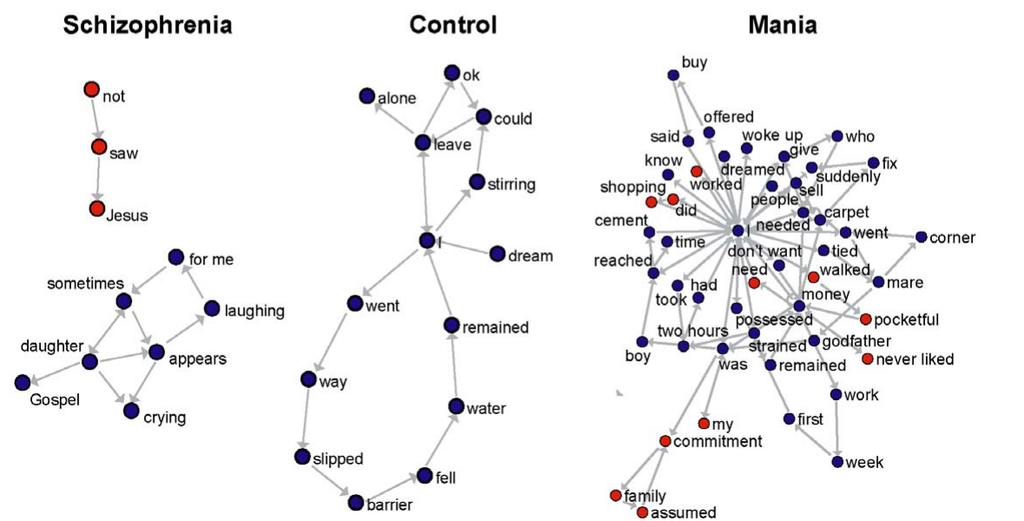

Figura 1C del paper, CC BY. Un paciente representativo por grupo; nodos rojos: vigilia

## Medidas crudas: la manía gana en diez

**N**M > S  
P = 0.003

**E**M > S  
P = 0.003

**LCC**M > S  
P = 0.005

**LSC**M > S  
P = 0.008

**ATD**M > S  
P = 0.007

**PE**M > S  
P = 0.003

**L1**sin  
diferencia

**L2**M > S  
P = 0.003

**L3**M > S  
P = 0.005

**WN**M > S  
P = 0.006

**WE**M > S  
P = 0.001

**D**sin  
diferencia

**DI**sin  
diferencia

**ASP**sin  
diferencia

- **N y E** más altos: **logorrea**. **Conectividad y recurrencia** más bajas en esquizofrenia: **pobreza del habla**. **WN y WE** más altos: **fuga de ideas**.
- Las tres globales no distinguen a nadie.

Pero los maníacos dijeron **muchas más palabras** por reporte ($P = 0.0006$). ¿Es todo verbosidad?

Figuras 2, 3, 4 y 5 del paper. Magenta: manía mayor que esquizofrenia con significancia

## Normalizadas por palabra: lo que sobrevive

**N**S > M  
P = 0.010

**E**sin  
diferencia

**LCC**sin  
diferencia

**LSC**sin  
diferencia

**ATD**S > M  
P = 0.005

**PE**M > S  
P = 0.004

**L1**sin  
diferencia

**L2**sin  
diferencia

**L3**sin  
diferencia

**WN**sin  
diferencia

**WE**M > S  
P = 0.015

**D**M > S  
P = 0.007

**DI**S > M  
P = 0.014

**ASP**S > M  
P = 0.010

**Esquizofrenia:** más nodos y más grado **por palabra**. Toca cada tema una sola vez, sin ramificar ni regresar.

**Manía:** más aristas paralelas y más aristas de vigilia **por palabra**. Regresa a lo mismo y se sale del tema, y eso **no** es solo hablar más.

Cada medida dividida entre el número de palabras del reporte. Figuras 6A y 7, Tabla S4

## Las globales normalizadas separan limpio

[figure not shown]

Los dos grupos clínicos tienen **poca varianza** y quedan en extremos opuestos. Los controles **cubren todo el rango** entre ambos: sin patología hay más variedad entre personas.

Rangos y medianas leídos de la figura 7 del paper; aproximados. D: P = 0.007; DI: P = 0.0138; ASP: P = 0.0104

## Las escalas no distinguen manía de esquizofrenia

| Comparación | BPRS | PANSS | Grafo normalizado |
| --- | --- | --- | --- |
| Esquizofrenia vs control | P = 0.0003 | P = 0.0003 | N, L1, L2 |
| Manía vs control | P = 0.0012 | P = 0.0006 | L1, L2, L3 |
| Esquizofrenia vs manía | P = 0.14 | P = 0.11 | 7 medidas, P < 0.015 |

Ninguna medida de grafo normalizada **correlaciona** con BPRS ni con PANSS (Tabla S5).

Las escalas dicen **cuánto** síntoma hay. El grafo dice **qué forma** tiene el habla. Miden cosas distintas: son **complementarias**.

Figura 6B, Tablas S5 y S6

## Clasificación automática

[figure not shown]

Esquizofrenia contra manía con **N, E y ATD**: **93.8 %** de sensibilidad y **93.7 %** de especificidad, contra **62.5 %** con las escalas. Contra controles las escalas empatan o ganan.

Figura 8 y Tabla S6. RBF, MLP, SVM y árbol de decisión dan el mismo patrón; los mejores son RBF y naive Bayes

# 05Discusión

Qué dice la forma del grafo sobre el pensamiento

## Lo que miden los grafos

**La logorrea no es solo más palabras.** Es un discurso que se ramifica más y regresa más veces al mismo punto: más aristas paralelas por palabra.

**La fuga de ideas es estructural.** Más aristas de vigilia por palabra, no por hablar más tiempo.

**La pobreza del habla es no regresar.** Más nodos y más grado por palabra: cada tema se toca una vez y se abandona.

**Lazos y estabilidad.** En redes, más lazos es menos estabilidad dinámica. Encaja con el curso cíclico de la manía y el curso monótono de la esquizofrenia.

La relación entre lazos y estabilidad es de Ma'ayan et al. (2008), que el paper cita

## Límites

- **8 por grupo** y grafos de 84 palabras. El paper lo reconoce y pide muestras más grandes.
- Pacientes **medicados y fuera de la fase aguda**: no es el cuadro de urgencias donde más urge el diagnóstico.
- **WN y WE** se contaron a mano y requieren juicio semántico. Por eso el clasificador no las usa.
- Portugués, un solo tema, una sola entrevistadora.

## Conclusiones

**La estructura del habla se mide.** Con grafos, sin interpretar el contenido. Doce de las catorce medidas son pura forma.

**Manía y esquizofrenia deforman el grafo al revés.** Denso y recurrente contra lineal y sin regreso.

**Complementa a las escalas.** Separa justo lo que BPRS y PANSS no separan, y no correlaciona con ellas.

**Hacia un diagnóstico automatizado.** Basado no en qué se dice, sino en cómo se dice. El paper lo llama un test de Turing psiquiátrico.

## Referencias

- N. B. Mota, N. A. P. Vasconcelos, N. Lemos, A. C. Pieretti, O. Kinouchi, G. A. Cecchi, M. Copelli y S. Ribeiro. *Speech Graphs Provide a Quantitative Measure of Thought Disorder in Psychosis*. PLoS ONE 7(4): e34928, 2012.
- R. Ferrer i Cancho y R. V. Solé. *The Small World of Human Language*. Proc. R. Soc. Lond. B 268: 2261-2265, 2001.
- M. Sigman y G. A. Cecchi. *Global organization of the Wordnet lexicon*. PNAS 99: 1742-1747, 2002.
- A. Ma'ayan et al. *Ordered cyclic motifs contribute to dynamic stability in biological and engineered networks*. PNAS 105: 19235-19240, 2008.
- S. R. Kay, A. Fiszbein y L. A. Opler. *The positive and negative syndrome scale (PANSS) for schizophrenia*. Schizophr. Bull. 13: 261-276, 1987.